# My choice:

Instead of following the instructors and doing the lesson in Google Colab, I preferred Jupyter, since I already had it installed from the "Hashtag" course, a few weeks ago.

# What I did on May 24, 2022:

### 1) Imported pandas "as" pd (a nickname)

### 2) Imported data from gist and at the same time creatind a variable "url" containing the imported data.

### 3) Named "dados" the variable containing the csv result of "url".

### 4) Gave the command "head", which shows:

a- The first five entries of the Data Frame (DF) if you leave the ".head" parenthesis empty;

b- The "n" entries if you fill the ".head" parenthesis with a number.

# I had to stop and I'm continuing the morning after.

Ok, let's do the lesson!

### Note that the code cells here are re-executable.

You may change a parameter and run again.

A different result will display in place of the former one.

### I guess everytime you enter here you must run all cells again to re-arrange the setup.

```python
import pandas as pd
url = "https://gist.githubusercontent.com/tgcsantos/3bdb29eba6ce391e90df2b72205ba891/raw/22fa920e80c9fa209a9fccc8b52d74cc95d1599b/dados_imoveis.csv"
dados = pd.read_csv(url)
dados.head()
```

|  | Rua | Bairro | Cidade | Metragem | Quartos | Banheiros | Vagas | Valor |
| --- | --- | --- | --- | --- | --- | --- | --- | --- |
| 0 | Avenida Itacira, 255 | Planalto Paulista | São Paulo | 1000 | 4 | 8 | 6 | R$ 7.000.000 |
| 1 | Rua Aurelia Perez Alvarez, 42 | Jardim dos Estados | São Paulo | 496 | 4 | 4 | 4 | R$ 3.700.000 |
| 2 | Rua Alba Valdez | Jardim Reimberg | São Paulo | 125 | 4 | 3 | 2 | R$ 380.000 |
| 3 | NaN | Jardim Morumbi | São Paulo | 310 | 3 | 2 | 4 | R$ 685.000 |
| 4 | Rua Tobias Barreto, 195 | Mooca | São Paulo | 100 | 3 | 2 | 2 | R$ 540.000 |

# Explaining the code above:

### "url=" means:

1) creating a variable called "url" (could be any other name, to avoid confusion with its origin);

2) the variable content is "called" from an url. Something that is at that address;

### "dados":

1) I know that url contains a raw tabular data = csv (The CSV, Comma Separated Values, file is a text file with a specific format to enable saving the data in a table-structured format.)

2) A variable named "dados" contains csv data from another just created variable called "url";

3) "dados" contains the Pandas reading of the imported "url" variable's tabular data.

### "dados.head()" displays:

a- The first five entries of the Data Frame (DF);

b- The "n" entries if you fill the ".head" parenthesis with a number. You may try it in the above code.

### One of the teachers always commands "head" first thing to check if the DF was imported ok.

# knowing more about the just imported DF

Just type the variable name that containd the imported DF: "dados", as below.

The DF will be displayed: the 1st five lines and the last 5.

After that an important info is given: "10008 rows × 8 columns" = the size of the table.

```python
dados
```

|  | Rua | Bairro | Cidade | Metragem | Quartos | Banheiros | Vagas | Valor |
| --- | --- | --- | --- | --- | --- | --- | --- | --- |
| 0 | Avenida Itacira, 255 | Planalto Paulista | São Paulo | 1000 | 4 | 8 | 6 | R$ 7.000.000 |
| 1 | Rua Aurelia Perez Alvarez, 42 | Jardim dos Estados | São Paulo | 496 | 4 | 4 | 4 | R$ 3.700.000 |
| 2 | Rua Alba Valdez | Jardim Reimberg | São Paulo | 125 | 4 | 3 | 2 | R$ 380.000 |
| 3 | NaN | Jardim Morumbi | São Paulo | 310 | 3 | 2 | 4 | R$ 685.000 |
| 4 | Rua Tobias Barreto, 195 | Mooca | São Paulo | 100 | 3 | 2 | 2 | R$ 540.000 |
| ... | ... | ... | ... | ... | ... | ... | ... | ... |
| 10003 | Rua Tapuçu | Vila Sofia | São Paulo | 95 | 2 | 2 | 2 | R$ 665.000 |
| 10004 | Rua Guararema | Bosque da Saúde | São Paulo | 605 | 8 | 7 | 5 | R$ 2.300.000 |
| 10005 | Rua Estero Belaco | Vila da Saúde | São Paulo | 205 | 3 | 3 | 6 | R$ 1.050.000 |
| 10006 | Rua Manuel Onha, , 514 | Vila Oratório | São Paulo | 185 | 3 | 2 | 2 | R$ 2.200\n /Mês |
| 10007 | Rua Barão de Tramandaí, 0 | Vila Alpina | São Paulo | 122 | 3 | 2 | 2 | R$ 270.000 |

10008 rows × 8 columns

### From the 2 displayed data above we can see that there are things to be cleaned/corrected in the DF:

1) Missing street names;

2) Currency symbols (all lines) and words (line 10006 at least) mixed with numbers at the "Valor" column;

3) Double comma in line 10006's address;

4) Whatever comes next.

### If I want to see more from the DF:

"dados.sample()" displays 1 RANDOM line.

By filling the parenthesis with a number, that quantity of random lines will be displayed.

```python
dados.sample()
```

|  | Rua | Bairro | Cidade | Metragem | Quartos | Banheiros | Vagas | Valor |
| --- | --- | --- | --- | --- | --- | --- | --- | --- |
| 14 | Rua João Antunes Carvalho, 75 | Lauzane Paulista | São Paulo | 300 | 4 | 5 | 4 | R$ 1.150.000 |

```python
dados.sample(15)
```

|  | Rua | Bairro | Cidade | Metragem | Quartos | Banheiros | Vagas | Valor |
| --- | --- | --- | --- | --- | --- | --- | --- | --- |
| 557 | Rua Aleixo Jorge, 190 | Sumaré | São Paulo | 150 | 4 | 1 | 2 | R$ 1.500.000 |
| 2046 | NaN | Jardim Guedala | São Paulo | 742 | 5 | 7 | 6 | R$ 3.400.000 |
| 2072 | Rua Dom Duarte Leopoldo | Cambuci | São Paulo | 88 | 2 | 2 | 1 | R$ 595.000 |
| 5152 | Rua Dom Tomás Costa e Lima, , 145 | Vila Tramontano | São Paulo | 388 | 3 | 6 | 5 | R$ 4.890.000 |
| 5196 | Rua Nicolau Barreto | Vila Cordeiro | São Paulo | 85 | 2 | 1 | 1 | R$ 530.000 |
| 3289 | NaN | Jardim Paulistano | São Paulo | 605 | 4 | 4 | 4 | R$ 12.720.000 |
| 5054 | Rua Santo Eufredo | Jardim Guedala | São Paulo | 768 | 4 | 5 | 5 | R$ 5.400.000 |
| 2489 | NaN | Boaçava | São Paulo | 488 | 5 | 7 | 6 | R$ 4.250.000 |
| 3961 | NaN | Jardim Europa | São Paulo | 1050 | 6 | 6 | 10 | R$ 18.000.000 |
| 7617 | Rua Doutor Fernandes Coelho | Pinheiros | São Paulo | 490 | 5 | 3 | 5 | R$ 7.000.000 |
| 9400 | Rua Diogo Rodrigues Marques | Jardim Ernestina | São Paulo | 137 | 3 | 3 | 2 | R$ 580.000 |
| 7002 | NaN | Fazenda Morumbi | São Paulo | 755 | 4 | 4 | 5 | R$ 2.650.000 |
| 9882 | NaN | Jardim Paulista | São Paulo | 575 | 4 | 6 | 4 | R$ 11.000.000 |
| 7242 | NaN | Vila Caraguatá | São Paulo | 160 | 4 | 2 | 2 | R$ 480.000 |
| 6591 | NaN | Mooca | São Paulo | 270 | 4 | 3 | 3 | R$ 1.200.000 |

# To get a "series":

Series means:

1) "A Pandas Series is like a column in a table. It is a one-dimensional array holding data of any type".

2) "Series is a one-dimensional labeled array capable of holding data of any type (integer, string, float, python objects, etc.). The axis labels are collectively called index".

Check how to get it below: (be careful, it's case sensitive)

```python
dados["Bairro"]
```

```
0         Planalto Paulista
1        Jardim dos Estados
2           Jardim Reimberg
3            Jardim Morumbi
4                     Mooca
                ...
10003            Vila Sofia
10004       Bosque da Saúde
10005         Vila da Saúde
10006         Vila Oratório
10007           Vila Alpina
Name: Bairro, Length: 10008, dtype: object
```

Ok, there are 10008 rows = the total given by the "dados" command above.

But I bet the same does not happen with the Rua column, because there are data missing or typed wrongly.

Let`s check:

```python
dados["Rua"]
```

```
0                 Avenida Itacira, 255
1        Rua Aurelia Perez Alvarez, 42
2                       Rua Alba Valdez
3                                   NaN
4              Rua Tobias Barreto, 195
                      ...
10003                        Rua Tapuçu
10004                     Rua Guararema
10005                 Rua Estero Belaco
10006           Rua Manuel Onha, , 514
10007        Rua Barão de Tramandaí, 0
Name: Rua, Length: 10008, dtype: object
```

### Counting the "NaN" in "Rua":

```python
dados['Rua'].isna().sum()
```

```
3434
```

```python
3434/10008*100
```

```
34.31254996003197
```

So 34% of the DF does not have a street name. 1/3 is very significative!

What to do? Simply disregard? Erase them? Is the street nasme important or only the borrough matters?

Leave the streets there, I say. No harm so far.

Following the lesson:

What if I want to know the borrough of a certain row?

```python
dados["Bairro"][6522]
```

```
'Vila Paulo Silas'
```

Done!

With "dados.info" I get what kind of data is in each column.

```python
dados.info()
```

```
<class 'pandas.core.frame.DataFrame'>
RangeIndex: 10008 entries, 0 to 10007
Data columns (total 8 columns):
 #   Column     Non-Null Count  Dtype
---  ------     --------------  -----
 0   Rua        6574 non-null   object
 1   Bairro     9996 non-null   object
 2   Cidade     10008 non-null  object
 3   Metragem   10008 non-null  int64
 4   Quartos    10008 non-null  int64
 5   Banheiros  10008 non-null  int64
 6   Vagas      10008 non-null  int64
 7   Valor      10008 non-null  object
dtypes: int64(4), object(4)
memory usage: 625.6+ KB
```

In the "Dtype" column: Object means text and int64 means an integer number.

In the "Non-Null Count" column: how many valid data. In number of rows. Remember we have 10008 rows here.

So Rua and Bairro are incomplete.

And Valor has not the desired "int64" (integer numbers) kind of data. How to fix it? (later...)

To display a column we can command "dados["Rua"]"

as we did before...

OR...

"dados.Rua" (If the column name is one word (simple) the SAME result could ALSO be gotten this way)

Let's try:

```python
dados.Rua
```

```
0                 Avenida Itacira, 255
1        Rua Aurelia Perez Alvarez, 42
2                       Rua Alba Valdez
3                                   NaN
4              Rua Tobias Barreto, 195
                      ...
10003                        Rua Tapuçu
10004                     Rua Guararema
10005                 Rua Estero Belaco
10006           Rua Manuel Onha, , 514
10007        Rua Barão de Tramandaí, 0
Name: Rua, Length: 10008, dtype: object
```

Ok. So let`s calculate the average square meters using that:

```python
dados.Metragem.mean()
```

```
442.30065947242207
```

So the mean square area of the properties is 442.3 square meters.

```python
dados["Metragem"].mean()
```

```
442.30065947242207
```

If you want to take a look at a bunch of "square meters", just take the "mean" off the above code, like that:

```python
dados["Metragem"]
```

```
0        1000
1         496
2         125
3         310
4         100
         ...
10003      95
10004     605
10005     205
10006     185
10007     122
Name: Metragem, Length: 10008, dtype: int64
```

My remark:

You see? It looks like we have rather large apartments or houses here. Does that mean high income rate by household?

Another observation is that all the rows in this series are dully filled.

Continuing on May 26.

My remark:

### If there is any text cell that should be "markdown" running as "code", the "run all" stops at the error.

So watch out! Every new cell is born as "code".

If you want text, change it in the header's due option box.

### What is the average square meters in Vila Mariana?

1) Check if there is Vila Mariana in the DF;

2) just to paractice: If yes, check how many (one thing at a time, not a function).

```python
dados["Bairro"] == "Vila Mariana"
```

```
0        False
1        False
2        False
3        False
4        False
         ...
10003    False
10004    False
10005    False
10006    False
10007    False
Name: Bairro, Length: 10008, dtype: bool
```

```python
(dados["Bairro"] == "Vila Mariana") *1
```

```
0        0
1        0
2        0
3        0
4        0
        ..
10003    0
10004    0
10005    0
10006    0
10007    0
Name: Bairro, Length: 10008, dtype: int32
```

```python
sum((dados["Bairro"] == "Vila Mariana") *1)
```

```
184
```

Ok, now we see there are 184 properties in Vila Mariana.

# No one told us if they are apartments or houses

But there is a "Vagas" column. That means apartments with "n" places to park per apartment.

When dealing with houses they usually don't talk about "Vagas", places to park).

Continuing...

```python
tem_imoveis_vila =(dados["Bairro"] == "Vila Mariana")
```

```python
tem_imoveis_vila
```

```
0        False
1        False
2        False
3        False
4        False
         ...
10003    False
10004    False
10005    False
10006    False
10007    False
Name: Bairro, Length: 10008, dtype: bool
```

Now we crop the "tem_imoveis_vila" from "dados":

```python
dados[tem_imoveis_vila]
```

|  | Rua | Bairro | Cidade | Metragem | Quartos | Banheiros | Vagas | Valor |
| --- | --- | --- | --- | --- | --- | --- | --- | --- |
| 100 | Rua Pero Correia | Vila Mariana | São Paulo | 250 | 3 | 3 | 1 | R$ 1.350.000 |
| 120 | Praça Doutor Carvalho Franco | Vila Mariana | São Paulo | 250 | 3 | 5 | 2 | R$ 2.450.000 |
| 155 | Rua Professor João Marinho | Vila Mariana | São Paulo | 170 | 3 | 4 | 2 | R$ 1.490.000 |
| 160 | NaN | Vila Mariana | São Paulo | 228 | 4 | 5 | 3 | R$ 2.200.000 |
| 334 | Rua Pero Correia, 892 | Vila Mariana | São Paulo | 350 | 6 | 4 | 10 | R$ 1.700.000 |
| ... | ... | ... | ... | ... | ... | ... | ... | ... |
| 9645 | Rua Sousa Ramos | Vila Mariana | São Paulo | 285 | 3 | 5 | 5 | R$ 1.650.000 |
| 9701 | Rua Benito Juarez | Vila Mariana | São Paulo | 171 | 3 | 2 | 4 | R$ 1.650.000 |
| 9737 | Rua Benito Juarez | Vila Mariana | São Paulo | 171 | 3 | 2 | 4 | R$ 1.650.000 |
| 9807 | NaN | Vila Mariana | São Paulo | 275 | 3 | 1 | 6 | R$ 1.500.000 |
| 9852 | Rua França Pinto | Vila Mariana | São Paulo | 280 | 3 | 3 | 4 | R$ 1.600.000 |

184 rows × 8 columns

Now we put this result in a variable:

```python
imoveis_na_vila_mariana =dados[tem_imoveis_vila]
```

Done. From this variable, that now became a smaller DF, we request the square meter average.

```python
imoveis_na_vila_mariana["Metragem"].mean()
```

```
233.6195652173913
```

Ready!

Comparing the Vila average area x the whole DF average area: (my own idea)

```python
(imoveis_na_vila_mariana["Metragem"].mean() / dados.Metragem.mean())*100
```

```
52.819176325907726
```

Ok! The average area in Vila Mariana is 52.819176325907726 per cent of the total average.

It's a large apartment for Sao Paulo standard, though. Both figures are, in fact.

### Now: How many apartments per neighborhood?

```python
dados["Bairro"].value_counts()
```

```
Alto de Pinheiros     409
Jardim Guedala        403
Jardim Paulista       309
Brooklin Paulista     247
Jardim Europa         240
                     ...
Jardim das Imbuias      1
Vila Represa            1
Vila Nancy              1
Sítio Represa           1
Vila Invernada          1
Name: Bairro, Length: 701, dtype: int64
```

Put it in a variable:

```python
n_imoveis_bairro = dados["Bairro"].value_counts()
```

Plot a graph of the 10 "Bairros" with more properties:

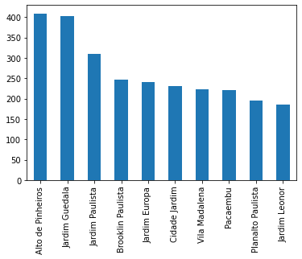

```python
n_imoveis_bairro.head(10).plot.bar()
```

# LESSON 2

## "Cleaning" the DF where necessary

### "A LOT of time in data science is spent in cleaning dataframes badly filled".

i.e. transforming "Valor" column from "object" to "int64"

= from mixed *text plus numbers* plus *thousand-points (do we need to clean them?)* to **only numbers**.

Let's chech the data info:

```python
dados.info()
```

```
<class 'pandas.core.frame.DataFrame'>
RangeIndex: 10008 entries, 0 to 10007
Data columns (total 8 columns):
 #   Column     Non-Null Count  Dtype
---  ------     --------------  -----
 0   Rua        6574 non-null   object
 1   Bairro     9996 non-null   object
 2   Cidade     10008 non-null  object
 3   Metragem   10008 non-null  int64
 4   Quartos    10008 non-null  int64
 5   Banheiros  10008 non-null  int64
 6   Vagas      10008 non-null  int64
 7   Valor      10008 non-null  object
dtypes: int64(4), object(4)
memory usage: 625.6+ KB
```

One example of how it is now:

```python
dados["Valor"][0]
```

```
'R$ 7.000.000'
```

### Let's apply the "split" method:

```python
dados["Valor"][0].split()
```

```
['R$', '7.000.000']
```

### It created an array with 2 elements: the dollar sign and the number itself.

But there may be more problems. Let's take a lok at a DF sample:

```python
dados.sample(10)
```

|  | Rua | Bairro | Cidade | Metragem | Quartos | Banheiros | Vagas | Valor |
| --- | --- | --- | --- | --- | --- | --- | --- | --- |
| 6382 | Rua Berlioz | Alto de Pinheiros | São Paulo | 299 | 5 | 2 | 5 | R$ 2.200.000 |
| 3616 | NaN | Jardim Guedala | São Paulo | 455 | 3 | 4 | 7 | R$ 3.400.000 |
| 530 | Rua Porangaba, 161 | Bosque da Saúde | São Paulo | 205 | 4 | 1 | 4 | R$ 1.332.000 |
| 1080 | Rua Manduri | Jardim Paulistano | São Paulo | 405 | 4 | 3 | 3 | R$ 6.300.000 |
| 4672 | Rua Alberto Faria, 1300 | Alto de Pinheiros | São Paulo | 523 | 5 | 1 | 6 | R$ 6.890.000 |
| 8223 | NaN | Sumaré | São Paulo | 165 | 8 | 3 | 5 | R$ 8.500\n /Mês |
| 8310 | Rua Corneteiro de Jesus | Água Fria | São Paulo | 250 | 3 | 4 | 2 | R$ 1.200.000 |
| 1977 | NaN | Jardim Paulistano | São Paulo | 529 | 5 | 3 | 5 | R$ 12.000.000 |
| 2109 | Rua Constantino Fraga, , 26 | Vila Hamburguesa | São Paulo | 140 | 2 | 2 | 3 | R$ 980.000 |
| 364 | Rua Pedro Rodrigues Marques, 0 | Jardim Ana Maria | São Paulo | 88 | 2 | 3 | 2 | R$ 360.000 |

"That's the real world", they say.

And I say:

- Who typed that dataframe? Who is that person's boss? Who is the client that accepted that crap???

And:

- Who are we programmers that did not invent an ML code to mass clean ALL DFs (in the world) automatically?

### The split method doesn't work in those cases.

So let's do this to the whole DF column including "str" = string, to be read accordingly:

```python
dados["Valor"].str.split()
```

```
0          [R$, 7.000.000]
1          [R$, 3.700.000]
2            [R$, 380.000]
3            [R$, 685.000]
4            [R$, 540.000]
               ...
10003        [R$, 665.000]
10004      [R$, 2.300.000]
10005      [R$, 1.050.000]
10006    [R$, 2.200, /Mês]
10007        [R$, 270.000]
Name: Valor, Length: 10008, dtype: object
```

#### dados["Valor"].str.split() generated a CSV (Comma Separated Values) series.

### Let's create one new column for each comma separated value in our DF:

```python
dados["Valor"].str.split(expand = True)
```

|  | 0 | 1 | 2 |
| --- | --- | --- | --- |
| 0 | R$ | 7.000.000 | None |
| 1 | R$ | 3.700.000 | None |
| 2 | R$ | 380.000 | None |
| 3 | R$ | 685.000 | None |
| 4 | R$ | 540.000 | None |
| ... | ... | ... | ... |
| 10003 | R$ | 665.000 | None |
| 10004 | R$ | 2.300.000 | None |
| 10005 | R$ | 1.050.000 | None |
| 10006 | R$ | 2.200 | /Mês |
| 10007 | R$ | 270.000 | None |

10008 rows × 3 columns

### Now make sure that column zero has one unique type of data:

```python
dados["Valor"].str.split(expand = True)[0].unique()
```

```
array(['R$'], dtype=object)
```

### It's telling us the currency sign is the only data type there.

Let's do it to column 1:

```python
dados["Valor"].str.split(expand = True)[1].unique()
```

```
array(['7.000.000', '3.700.000', '380.000', ..., '553.000', '951.000',
       '2.200'], dtype=object)
```

Each value is considered a different type.

Let's check how many (by the "len" method) different values there are:

```python
len(dados["Valor"].str.split(expand = True)[1].unique())
```

```
1038
```

So 1038 different numbers!

We have 10008 rows and only 1038 values.

### The same query for column 2:

```python
dados["Valor"].str.split(expand = True)[2].unique()
```

```
array([None, '/Mês', '/Ano', '/Dia'], dtype=object)
```

### Adding the splitted array (now 3 columns w/ 3 new names) to the Dados DF:

"Tipo_anuncio" means: We suppose thar None meand sell; Mes, ano and dia mean rental by those periods.

```python
dados[["Moeda", "Valor_anuncio", "Tipo_anuncio"]] = dados["Valor"].str.split(expand = True)
dados.head()
```

|  | Rua | Bairro | Cidade | Metragem | Quartos | Banheiros | Vagas | Valor | Moeda | Valor_anuncio | Tipo_anuncio |
| --- | --- | --- | --- | --- | --- | --- | --- | --- | --- | --- | --- |
| 0 | Avenida Itacira, 255 | Planalto Paulista | São Paulo | 1000 | 4 | 8 | 6 | R$ 7.000.000 | R$ | 7.000.000 | None |
| 1 | Rua Aurelia Perez Alvarez, 42 | Jardim dos Estados | São Paulo | 496 | 4 | 4 | 4 | R$ 3.700.000 | R$ | 3.700.000 | None |
| 2 | Rua Alba Valdez | Jardim Reimberg | São Paulo | 125 | 4 | 3 | 2 | R$ 380.000 | R$ | 380.000 | None |
| 3 | NaN | Jardim Morumbi | São Paulo | 310 | 3 | 2 | 4 | R$ 685.000 | R$ | 685.000 | None |
| 4 | Rua Tobias Barreto, 195 | Mooca | São Paulo | 100 | 3 | 2 | 2 | R$ 540.000 | R$ | 540.000 | None |

We are interested only in the "None" Tipo_anuncio.

Will delete all the others. Filter and delete.

```python
dados["Tipo_anuncio"].isnull()
```

```
0         True
1         True
2         True
3         True
4         True
         ...
10003     True
10004     True
10005     True
10006    False
10007     True
Name: Tipo_anuncio, Length: 10008, dtype: bool
```

Crop the DF by the above result:

```python
dados[dados["Tipo_anuncio"].isnull()]
```

|  | Rua | Bairro | Cidade | Metragem | Quartos | Banheiros | Vagas | Valor | Moeda | Valor_anuncio | Tipo_anuncio |
| --- | --- | --- | --- | --- | --- | --- | --- | --- | --- | --- | --- |
| 0 | Avenida Itacira, 255 | Planalto Paulista | São Paulo | 1000 | 4 | 8 | 6 | R$ 7.000.000 | R$ | 7.000.000 | None |
| 1 | Rua Aurelia Perez Alvarez, 42 | Jardim dos Estados | São Paulo | 496 | 4 | 4 | 4 | R$ 3.700.000 | R$ | 3.700.000 | None |
| 2 | Rua Alba Valdez | Jardim Reimberg | São Paulo | 125 | 4 | 3 | 2 | R$ 380.000 | R$ | 380.000 | None |
| 3 | NaN | Jardim Morumbi | São Paulo | 310 | 3 | 2 | 4 | R$ 685.000 | R$ | 685.000 | None |
| 4 | Rua Tobias Barreto, 195 | Mooca | São Paulo | 100 | 3 | 2 | 2 | R$ 540.000 | R$ | 540.000 | None |
| ... | ... | ... | ... | ... | ... | ... | ... | ... | ... | ... | ... |
| 10002 | Avenida Odila | Planalto Paulista | São Paulo | 267 | 3 | 6 | 4 | R$ 1.500.000 | R$ | 1.500.000 | None |
| 10003 | Rua Tapuçu | Vila Sofia | São Paulo | 95 | 2 | 2 | 2 | R$ 665.000 | R$ | 665.000 | None |
| 10004 | Rua Guararema | Bosque da Saúde | São Paulo | 605 | 8 | 7 | 5 | R$ 2.300.000 | R$ | 2.300.000 | None |
| 10005 | Rua Estero Belaco | Vila da Saúde | São Paulo | 205 | 3 | 3 | 6 | R$ 1.050.000 | R$ | 1.050.000 | None |
| 10007 | Rua Barão de Tramandaí, 0 | Vila Alpina | São Paulo | 122 | 3 | 2 | 2 | R$ 270.000 | R$ | 270.000 | None |

9156 rows × 11 columns

Ok. Now check if "Tipo_anuncio" is unique.

```python
dados[dados["Tipo_anuncio"].isnull()]["Tipo_anuncio"].unique()
```

```
array([None], dtype=object)
```

Worked! Only "None" in that column.

Now insert it in the mainDF and rename the DF to "dados_vendas" so we can compare with the original "dados".

Otherwise the original complete data would be lost.

```python
dados_vendas = dados[dados["Tipo_anuncio"].isnull()]
dados_vendas
```

|  | Rua | Bairro | Cidade | Metragem | Quartos | Banheiros | Vagas | Valor | Moeda | Valor_anuncio | Tipo_anuncio |
| --- | --- | --- | --- | --- | --- | --- | --- | --- | --- | --- | --- |
| 0 | Avenida Itacira, 255 | Planalto Paulista | São Paulo | 1000 | 4 | 8 | 6 | R$ 7.000.000 | R$ | 7.000.000 | None |
| 1 | Rua Aurelia Perez Alvarez, 42 | Jardim dos Estados | São Paulo | 496 | 4 | 4 | 4 | R$ 3.700.000 | R$ | 3.700.000 | None |
| 2 | Rua Alba Valdez | Jardim Reimberg | São Paulo | 125 | 4 | 3 | 2 | R$ 380.000 | R$ | 380.000 | None |
| 3 | NaN | Jardim Morumbi | São Paulo | 310 | 3 | 2 | 4 | R$ 685.000 | R$ | 685.000 | None |
| 4 | Rua Tobias Barreto, 195 | Mooca | São Paulo | 100 | 3 | 2 | 2 | R$ 540.000 | R$ | 540.000 | None |
| ... | ... | ... | ... | ... | ... | ... | ... | ... | ... | ... | ... |
| 10002 | Avenida Odila | Planalto Paulista | São Paulo | 267 | 3 | 6 | 4 | R$ 1.500.000 | R$ | 1.500.000 | None |
| 10003 | Rua Tapuçu | Vila Sofia | São Paulo | 95 | 2 | 2 | 2 | R$ 665.000 | R$ | 665.000 | None |
| 10004 | Rua Guararema | Bosque da Saúde | São Paulo | 605 | 8 | 7 | 5 | R$ 2.300.000 | R$ | 2.300.000 | None |
| 10005 | Rua Estero Belaco | Vila da Saúde | São Paulo | 205 | 3 | 3 | 6 | R$ 1.050.000 | R$ | 1.050.000 | None |
| 10007 | Rua Barão de Tramandaí, 0 | Vila Alpina | São Paulo | 122 | 3 | 2 | 2 | R$ 270.000 | R$ | 270.000 | None |

9156 rows × 11 columns

### Now run all cells again is important, so many crops we did with the original.

We want the original back (way up above here).

## run all!

OK.